# Trabajo Final Módulo Ciencia de Datos

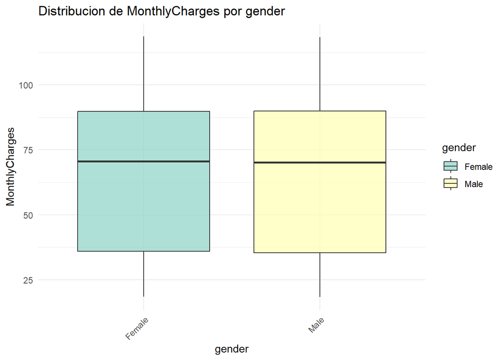

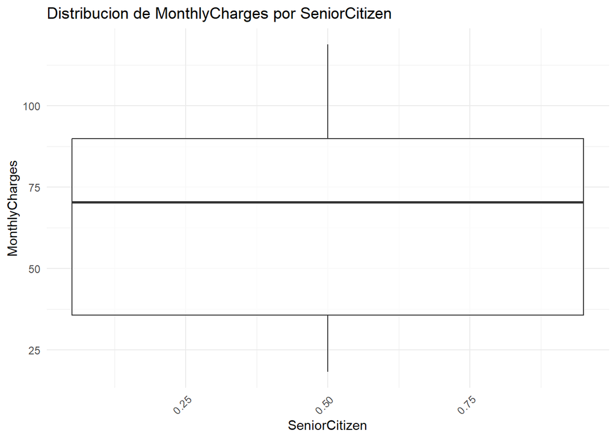

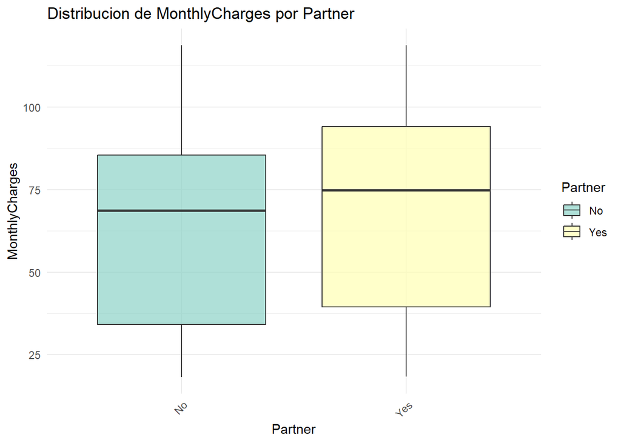

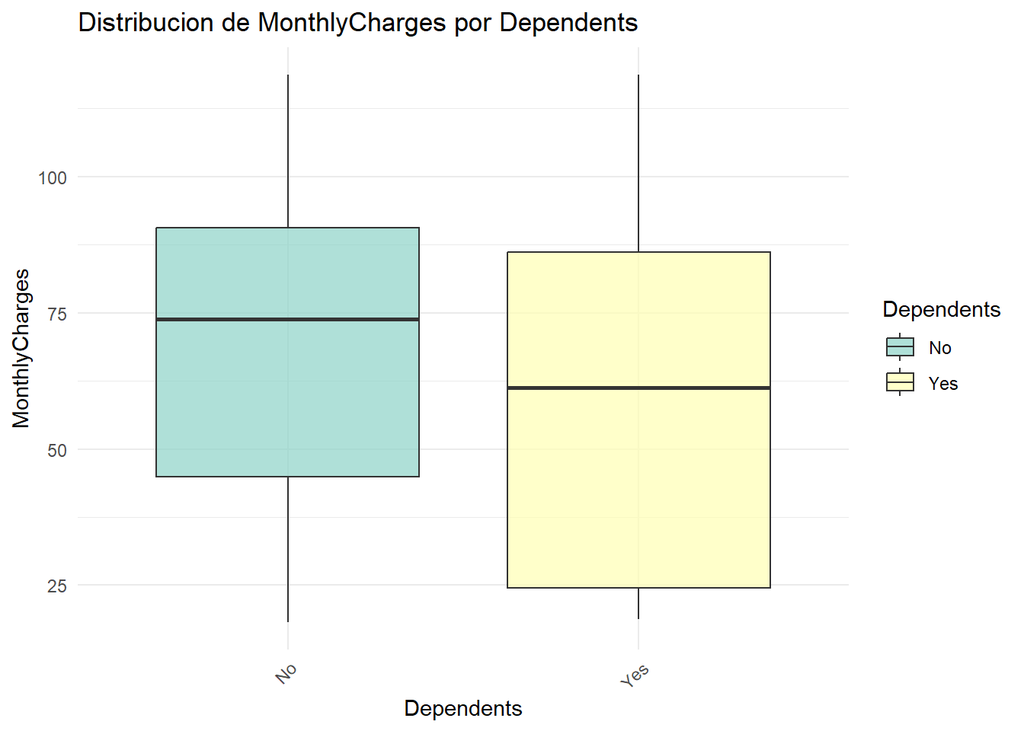

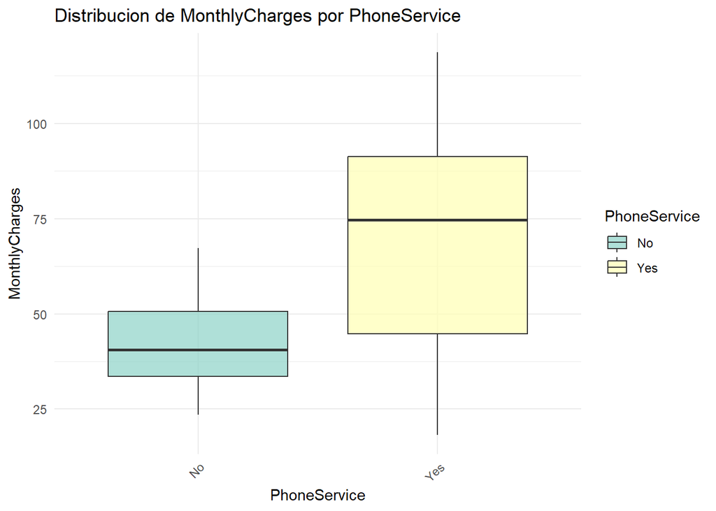

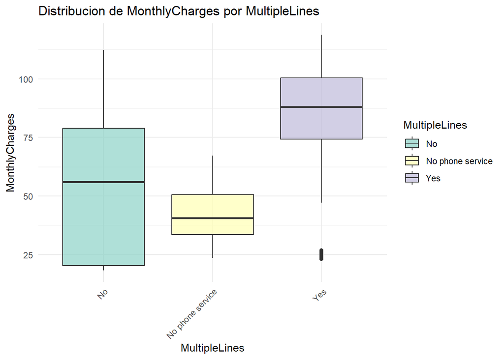

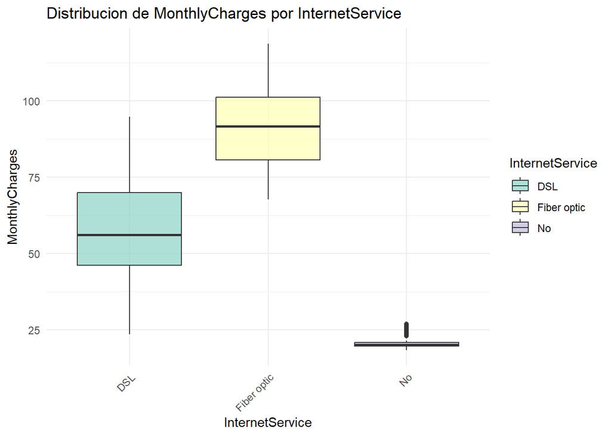

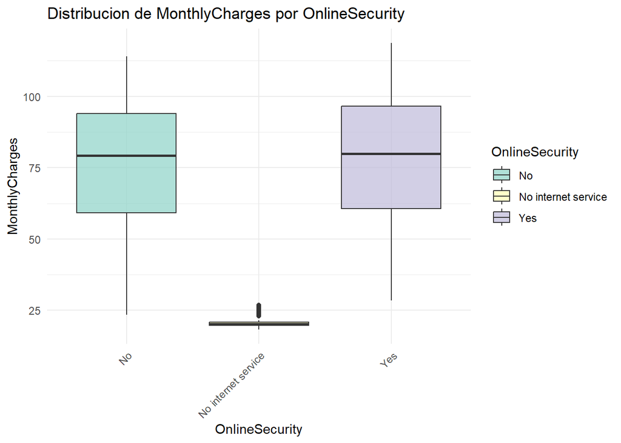

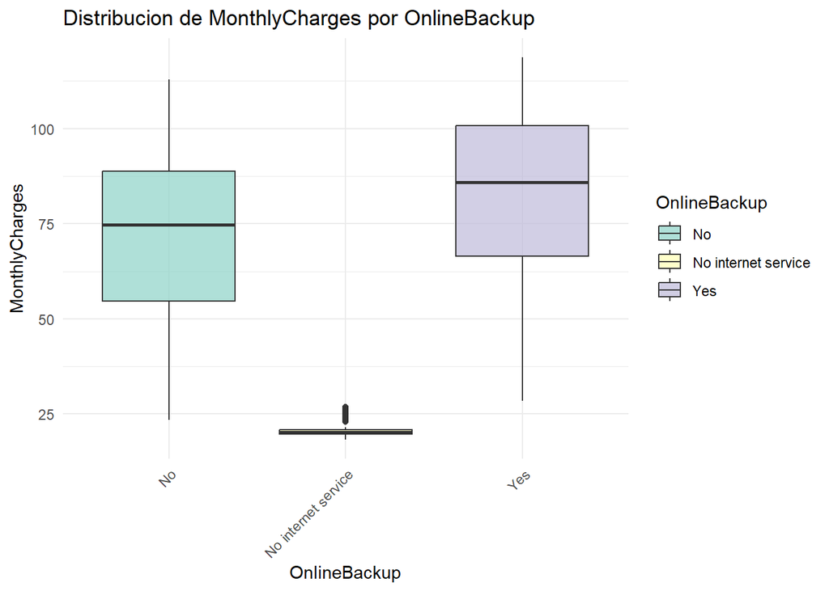

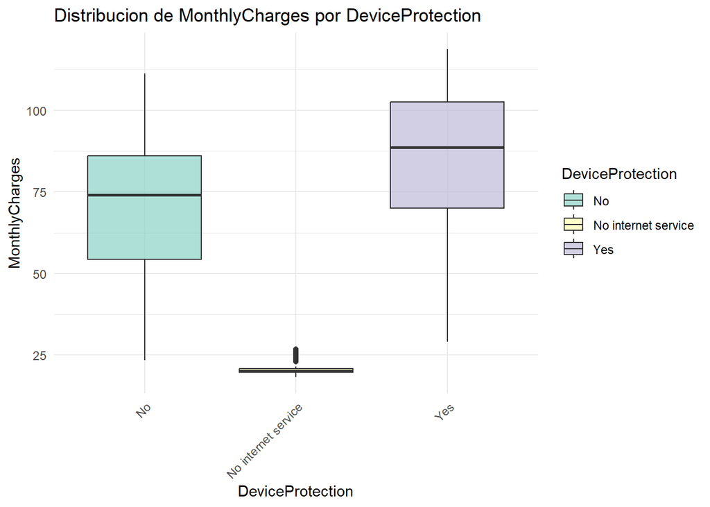

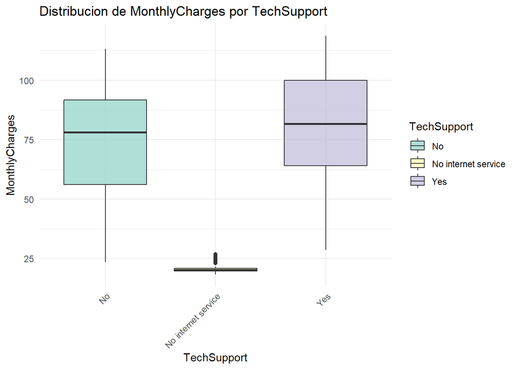

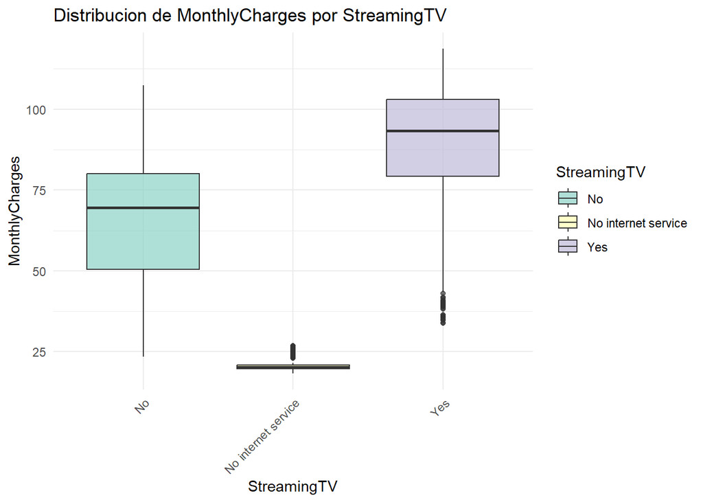

[4 more figures not shown]

  ```r
  #Variables categoricas
  categoricas <- c("gender", "SeniorCitizen", "Partner", "Dependents", "PhoneService",
            "MultipleLines", "InternetService", "OnlineSecurity", "OnlineBackup",
            "DeviceProtection", "TechSupport", "StreamingTV", "StreamingMovies",
            "Contract", "PaperlessBilling", "PaymentMethod")
  #Boxplot de variables categoricas
  for (c in categoricas) {
    bxp <- ggplot(churn_data, aes_string(x=c, y= "MonthlyCharges", fill= c))+
  geom_boxplot(alpha=0.7)+
  labs(title = paste("Distribucion de MonthlyCharges por", c),
       x = c, y = "MonthlyCharges")+
  theme_minimal()+
  theme(axis.text.x = element_text(angle = 45,hjust = 1))+
  scale_fill_brewer(palette = "Set3")
    print(bxp)
  }
  ```

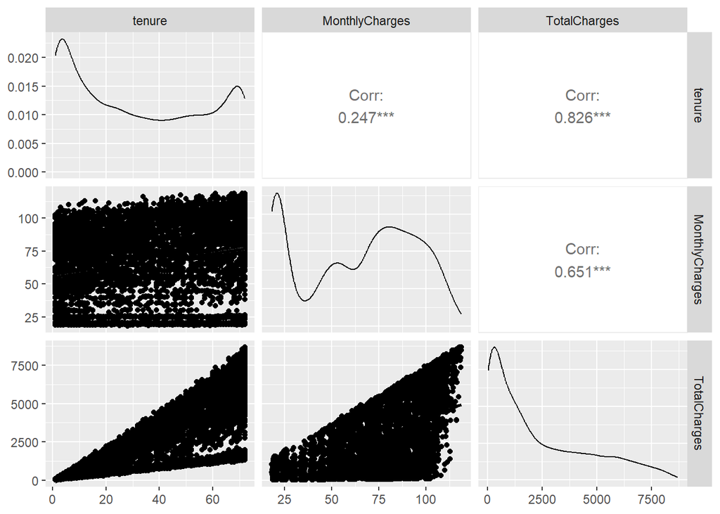

```r
# Lista de variables numéricas
disp <- churn_data[,c("tenure", "MonthlyCharges", "TotalCharges")]
#Grafico de dispersion conjunto
    ggpairs(disp,
            upper = list(continuous = "cor"),
            lower = list(continuous = "smooth"),
            diag = list(continuous = "densityDiag"))
```

- Cualquier otra cosa que se te ocurra y creas que da información sobre los problemas que queremos resolver en el proyecto.

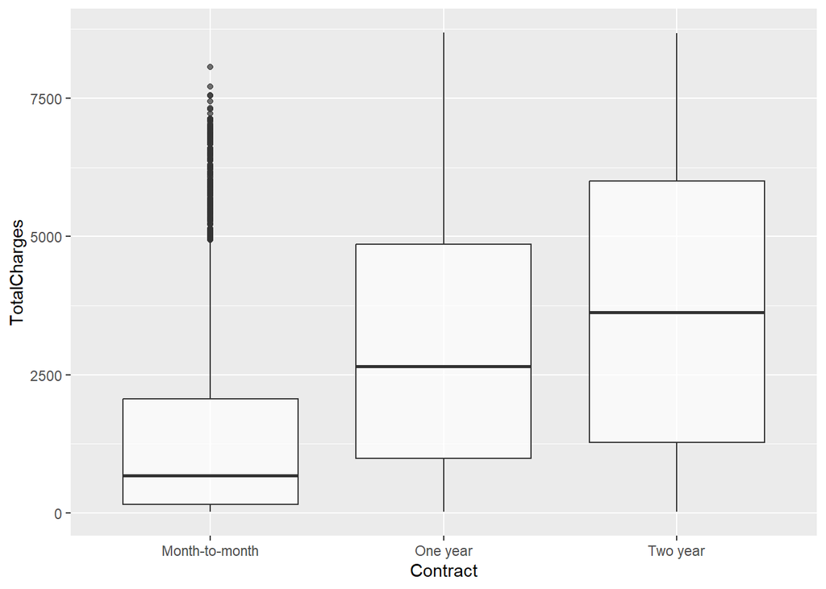

```r
#Facturacion por duracion de contrato
ggplot(churn_data, aes(x=Contract,y=TotalCharges))+
  geom_boxplot(binwidth = 5, alpha = 0.7)
```

En este proyecto en particular, los datos están limpios y no hay valores erróneos o anómalos. En general, esto es extraño que suceda y el proceso de análisis exploratorio te hubiera ayudado a encontrar y corregir estos errores. Si hay alguna variable que deba ser considerada como categórica en lugar de como numérica transfórmala. Es necesario para que los modelos de regresión o clasificación funcionen correctamente.

```r
#Cambiamos variable "SeniorCitizen" a categorica
churn_data$SeniorCitizen <- as.factor(churn_data$SeniorCitizen)
#Factorizamos "Churn" para utilizarlo de variable del modelo
churn_data$Churn <- as.factor(churn_data$Churn)
```

Antes de seguir adelante, vamos a dividir el conjunto de datos en dos subconjuntos de entrenamiento y test: - churn_train: Contendrá las 5000 primeras de churn_data - churn_test: Contendrá las filas de la 5001 al final de churn_data

```r
# Código para creación de conjuntos de entrenamiento y test
#Dividir el conjunto de datos
churn_train <- churn_data[1:5000, ]
churn_test <- churn_data[5001:nrow(churn_data), ]
#Me dio problemas mas adelante
churn_train_no_id <- churn_train[, !(names(churn_train) %in% c("customerID"))]
churn_test_no_id <- churn_test[, !(names(churn_test) %in% c("customerID"))]
```

Ajusta un modelo de regresión multilineal sobre los datos de entrenamiento churn_train: - Usa como variable objetivo MonthlyCharges - Usa como variables predictoras todas las demás menos customerId, TotalCharges y Churn.

```r
#Modelo de regresion lineal
mdl <- lm(MonthlyCharges~. - TotalCharges - Churn, data= churn_train_no_id)
```

Muestra los detalles del modelo ajustado mediante la función summary aplicada al objeto donde has almacenado el modelo ajustado.

```r
#Resumen del modelo
summary(mdl)
```

```
##
## Call:
## lm(formula = MonthlyCharges ~ . - TotalCharges - Churn, data = churn_train_no_id)
##
## Residuals:
##     Min      1Q  Median      3Q     Max
## -4.1927 -0.5992  0.0026  0.6025  4.8593
##
## Coefficients: (7 not defined because of singularities)
##                                        Estimate Std. Error  t value Pr(>|t|)
## (Intercept)                           2.493e+01  6.918e-02  360.357   <2e-16 ***
## genderMale                            7.461e-03  2.886e-02    0.259    0.796
## SeniorCitizen1                        1.183e-03  4.200e-02    0.028    0.978
## PartnerYes                           -1.705e-02  3.518e-02   -0.485    0.628
## DependentsYes                         3.445e-02  3.710e-02    0.928    0.353
## tenure                                4.699e-04  1.002e-03    0.469    0.639
## PhoneServiceYes                       2.007e+01  5.755e-02  348.781   <2e-16 ***
## MultipleLinesNo phone service                NA         NA       NA       NA
## MultipleLinesYes                      5.005e+00  3.460e-02  144.665   <2e-16 ***
## InternetServiceFiber optic            2.498e+01  4.087e-02  611.186   <2e-16 ***
## InternetServiceNo                    -2.505e+01  5.693e-02 -439.966   <2e-16 ***
## OnlineSecurityNo internet service            NA         NA       NA       NA
## OnlineSecurityYes                     4.995e+00  3.811e-02  131.085   <2e-16 ***
## OnlineBackupNo internet service              NA         NA       NA       NA
## OnlineBackupYes                       5.010e+00  3.576e-02  140.096   <2e-16 ***
## DeviceProtectionNo internet service          NA         NA       NA       NA
## DeviceProtectionYes                   5.024e+00  3.700e-02  135.786   <2e-16 ***
## TechSupportNo internet service               NA         NA       NA       NA
## TechSupportYes                        5.025e+00  3.899e-02  128.865   <2e-16 ***
## StreamingTVNo internet service               NA         NA       NA       NA
## StreamingTVYes                        9.944e+00  3.805e-02  261.318   <2e-16 ***
## StreamingMoviesNo internet service           NA         NA       NA       NA
## StreamingMoviesYes                    9.986e+00  3.798e-02  262.944   <2e-16 ***
## ContractOne year                      7.533e-03  4.540e-02    0.166    0.868
## ContractTwo year                     -1.692e-04  5.533e-02   -0.003    0.998
## PaperlessBillingYes                  -1.526e-03  3.233e-02   -0.047    0.962
## PaymentMethodCredit card (automatic) -6.455e-02  4.352e-02   -1.483    0.138
## PaymentMethodElectronic check        -1.711e-02  4.284e-02   -0.399    0.690
## PaymentMethodMailed check            -1.150e-02  4.676e-02   -0.246    0.806
## ---
## Signif. codes:  0 '***' 0.001 '**' 0.01 '*' 0.05 '.' 0.1 ' ' 1
##
## Residual standard error: 1.018 on 4978 degrees of freedom
## Multiple R-squared:  0.9989, Adjusted R-squared:  0.9989
## F-statistic: 2.081e+05 on 21 and 4978 DF,  p-value: < 2.2e-16
```

A partir del detalle sobre los coeficientes del modelo ajustado responde a las siguientes cuestiones: - ¿Cuáles son las variables/coeficientes que a un nivel de significancia del 95% podemos concluir que son no nulos?

```r
#Variables significativas al 95%
var <- summary(mdl)$coefficients[which(summary(mdl)$coefficients[,4]<0.05),1]
names(var)
```

```
##  [1] "(Intercept)"                "PhoneServiceYes"            "MultipleLinesYes"
##  [4] "InternetServiceFiber optic" "InternetServiceNo"          "OnlineSecurityYes"
##  [7] "OnlineBackupYes"            "DeviceProtectionYes"        "TechSupportYes"
## [10] "StreamingTVYes"             "StreamingMoviesYes"
```

Podriamos decir que todos los servicios adicionales a la linea de telefono o Internet como por ejemplo: - Multiples lineas de teléfono - Servicios de streaming - Seguros para los dispositivos - Fibra optica

A partir del valor de los coeficientes, ¿podrías estimar el coste de los diferentes servicios: teléfono, DSL, Fibra, seguridad, TV, etc.?

```r
#Resumen del modelo para obterner los coeficientes
model_summary <- summary(mdl)
#Extraer coeficientes del modelo
coefficients <- model_summary$coefficients

#Extraer coeficientes de interes
cost_multiplelineyes <- coefficients["MultipleLinesYes", "Estimate"]
cost_streamingtvyes <- coefficients["StreamingTVYes", "Estimate"]
cost_dsl <- coefficients["InternetServiceNo", "Estimate"]
cost_deviceprotection <- coefficients["DeviceProtectionYes", "Estimate"]
cost_internetservicefiberoptic <- coefficients["InternetServiceFiber optic", "Estimate"]

#Mostrar los resultados
print(paste("Coste adicional por tener MultipleLine:", round(cost_multiplelineyes, 2)))
```

```
## [1] "Coste adicional por tener MultipleLine: 5"
```

```r
print(paste("Coste adicional por tener StreamingTV:", round(cost_streamingtvyes, 2)))
```

```
## [1] "Coste adicional por tener StreamingTV: 9.94"
```

```r
print(paste("Coste adicional por tener InternetServiceNo:", round(cost_dsl, 2)))
```

```
## [1] "Coste adicional por tener InternetServiceNo: -25.05"
```

```r
print(paste("Coste adicional por tener DeviceProtection:", round(cost_deviceprotection, 2)))
```

```
## [1] "Coste adicional por tener DeviceProtection: 5.02"
```

```r
print(paste("Coste adicional por tener InternetService:", round(cost_internetservicefiberoptic, 2)))
```

```
## [1] "Coste adicional por tener InternetService: 24.98"
```

Ahora a partir del modelo ajustado, haz una predicción sobre el conjunto de test: churn_test y calcula el error promedio de las predicciones. Como métrica del error del las predicciones usaremos el RMSE (root mean square error) : 𝑅𝑀𝑆𝐸= √1𝑛Σ(𝑦𝑖− 𝑦̂𝑖)2

```r
#Prediccion del conjunto de prueba
pred <- predict(mdl, newdata= churn_test_no_id)

#Calcular RSME
rmse <- sqrt(mean((churn_test_no_id$MonthlyCharges-pred)^2))
rmse
```

```
## [1] 1.044388
```

# Modelos de clasificación

Vamos a diseñar y ajustar un modelo de Clasificación para predecir los clientes que pueden abandonar la compañía. Ajusta un modelo de regresión logística sobre los datos de entrenamiento churn_train: - Usa como variable objetivo Churn - Usa como variables predictoras todas menos customerId.

```r
#Modelo de regresión logistica
log_model <- glm(Churn ~. -TotalCharges, data = churn_train_no_id, family = binomial)

#Resumen del modelo
summary(log_model)
```

```
##
## Call:
## glm(formula = Churn ~ . - TotalCharges, family = binomial, data = churn_train_no_id)
##
## Coefficients: (7 not defined because of singularities)
##                                      Estimate Std. Error z value Pr(>|z|)
## (Intercept)                           1.57121    0.97545   1.611 0.107233
## genderMale                           -0.03785    0.07760  -0.488 0.625719
## SeniorCitizen1                        0.15754    0.10109   1.558 0.119132
## PartnerYes                            0.01980    0.09392   0.211 0.833066
## DependentsYes                        -0.15289    0.10790  -1.417 0.156479
## tenure                               -0.03395    0.00288 -11.788  < 2e-16 ***
## PhoneServiceYes                       0.92897    0.78708   1.180 0.237888
## MultipleLinesNo phone service              NA         NA      NA       NA
## MultipleLinesYes                      0.66484    0.21308   3.120 0.001808 **
## InternetServiceFiber optic            2.69302    0.96869   2.780 0.005435 **
## InternetServiceNo                    -2.67148    0.97688  -2.735 0.006243 **
## OnlineSecurityNo internet service          NA         NA      NA       NA
## OnlineSecurityYes                    -0.00989    0.21483  -0.046 0.963283
## OnlineBackupNo internet service            NA         NA      NA       NA
## OnlineBackupYes                       0.23763    0.21188   1.122 0.262054
## DeviceProtectionNo internet service        NA         NA      NA       NA
## DeviceProtectionYes                   0.33555    0.21293   1.576 0.115046
## TechSupportNo internet service             NA         NA      NA       NA
## TechSupportYes                       -0.10024    0.21792  -0.460 0.645516
## StreamingTVNo internet service             NA         NA      NA       NA
## StreamingTVYes                        1.00927    0.39547   2.552 0.010707 *
## StreamingMoviesNo internet service         NA         NA      NA       NA
## StreamingMoviesYes                    0.98755    0.39631   2.492 0.012708 *
## ContractOne year                     -0.62713    0.12868  -4.874 1.10e-06 ***
## ContractTwo year                     -1.46235    0.22309  -6.555 5.56e-11 ***
## PaperlessBillingYes                   0.32882    0.08895   3.697 0.000219 ***
## PaymentMethodCredit card (automatic) -0.10970    0.13703  -0.801 0.423390
## PaymentMethodElectronic check         0.36288    0.11264   3.222 0.001274 **
## PaymentMethodMailed check             0.02268    0.13633   0.166 0.867890
## MonthlyCharges                       -0.07140    0.03847  -1.856 0.063470 .
## ---
## Signif. codes:  0 '***' 0.001 '**' 0.01 '*' 0.05 '.' 0.1 ' ' 1
##
## (Dispersion parameter for binomial family taken to be 1)
##
##     Null deviance: 5765.8  on 4999  degrees of freedom
## Residual deviance: 4094.6  on 4977  degrees of freedom
## AIC: 4140.6
##
## Number of Fisher Scoring iterations: 6
```

Con el modelo ajustado, predice sobre los datos de test (churn_test) la probabilidad de abandono de los clientes. A partir de dicha probabilidad asigna a una variable churn_pred =”Yes” si prob >0.5 y “No” en caso contrario. Calcula la matriz de confusión de la predicción:

|  |  | Pred |
| --- | --- | --- |
| Real | No | Yes |
| No | TN | FP |
| Yes | FN | TP |

```r
# Realizar predicciones sobre el conjunto de prueba, obteniendo probabilidades
prob_pred <- predict(log_model,newdata = churn_test_no_id, type = "response")

# Asignar "Yes" o "No" en función de la probabilidad
churn_test_no_id$churn_pred <- ifelse(prob_pred > 0.5, "Yes", "No")

#Creamos la matrix de confusion
confusion_matrix <- table(Pred = churn_test_no_id$churn_pred, Real = churn_test_no_id$Churn)

#Mostramos la matriz de confusion
print(confusion_matrix)
```

```
##      Real
## Pred    No  Yes
##   No  1335  258
##   Yes  145  294
```

```r
# Extraer los valores de la matriz de confusión
TN <- confusion_matrix["No", "No"]   # Verdaderos Negativos
FP <- confusion_matrix["Yes", "No"]  # Falsos Positivos
FN <- confusion_matrix["No", "Yes"]  # Falsos Negativos
TP <- confusion_matrix["Yes", "Yes"] # Verdaderos Positivos

# Mostrar los resultados
print(paste("Verdaderos Negativos (TN):", TN))
```

```
## [1] "Verdaderos Negativos (TN): 1335"
```

```r
print(paste("Falsos Positivos (FP):", FP))
```

```
## [1] "Falsos Positivos (FP): 145"
```

```r
print(paste("Falsos Negativos (FN):", FN))
```

```
## [1] "Falsos Negativos (FN): 258"
```

```r
print(paste("Verdaderos Positivos (TP):", TP))
```

```
## [1] "Verdaderos Positivos (TP): 294"
```

A partir de ella calcula:

- La precisión global de la predicción: Accuracy = (TN + TP) / (TN + FN + FP + TP)

- La ratio de falsos positivos: FPR = FP / (FP + TN)

- La ratio de falsos negativos: FNR = FN / (FN + TP)

- La ratio de verdaderos positivos: TPR = TP / (FN + TP)

```r
#Calcular la precision global asi predecimos los clientes que abandonan como los que no
accuracy <- (TN + TP) / (TN + FN + FP + TP)
print(paste("Precisión global (Accuracy):", round(accuracy,3)))
```

```
## [1] "Precisión global (Accuracy): 0.802"
```

```r
#Calcular el ratio de falsos positivos, asi medimos la proporcion que el modelo predijo incorrectamente que el cliente
#abandonaria cuando en realidad no
FPR <- FP / (FP + TN)
print(paste("Ratio de falsos positivos(FPR):", round(FPR,3)))
```

```
## [1] "Ratio de falsos positivos(FPR): 0.098"
```

```r
#Calcular el ratio de falsos negativos, asi medimos la proporcion que el modelo predijo incorrectamente que el cliente
# abandonaria cuando en realidad si lo hizo
FNR <- FN / (FN + TP)
print(paste("Ratio de falsos Negativos(FNR):", round(FNR,3)))
```

```
## [1] "Ratio de falsos Negativos(FNR): 0.467"
```

```r
#Calcular la ratio de verdaderos positivos (Sensibilidad o TPR) modelo predice correctamente los clientes que abandonan
TPR <- TP / (FN + TP)
print(paste("Ratio de verdaderos positivos(TPR - Sensibilidad):", round(TPR,3)))
```

```
## [1] "Ratio de verdaderos positivos(TPR - Sensibilidad): 0.533"
```

Ahora, ajusta en el conjunto de entrenamiento un modelo de clasificación para la variable Churn que use como predictores solo Contract, Tenure e InternetService. Predice en el conjunto de test y calcula la matriz de confusión, así como las métricas que has calculado para el modelo anterior y compara los resultados.

```r
#Modelo simplificado
mod_clas_churn <- glm(Churn ~ Contract + tenure + InternetService, family = binomial, data = churn_train_no_id)
summary(mod_clas_churn)
```

```
##
## Call:
## glm(formula = Churn ~ Contract + tenure + InternetService, family = binomial,
##     data = churn_train_no_id)
##
## Coefficients:
##                             Estimate Std. Error z value Pr(>|z|)
## (Intercept)                -0.336150   0.074478  -4.513 6.38e-06 ***
## ContractOne year           -0.830329   0.123154  -6.742 1.56e-11 ***
## ContractTwo year           -1.849373   0.216546  -8.540  < 2e-16 ***
## tenure                     -0.031227   0.002328 -13.412  < 2e-16 ***
## InternetServiceFiber optic  1.212238   0.086492  14.016  < 2e-16 ***
## InternetServiceNo          -1.089605   0.141636  -7.693 1.44e-14 ***
## ---
## Signif. codes:  0 '***' 0.001 '**' 0.01 '*' 0.05 '.' 0.1 ' ' 1
##
## (Dispersion parameter for binomial family taken to be 1)
##
##     Null deviance: 5765.8  on 4999  degrees of freedom
## Residual deviance: 4264.6  on 4994  degrees of freedom
## AIC: 4276.6
##
## Number of Fisher Scoring iterations: 6
```

```r
#Realizar predicciones sobre el nuevo conjunto test
prob_pred_churn <-  predict(mod_clas_churn, newdata = churn_test_no_id, type = "response")

#Asignar "Yes" o "No" basado  en la probabilidad (umbral 0.5)
churn_test_no_id$churn_pred <- ifelse(prob_pred_churn > 0.5, "Yes", "No")

#Crear la matriz de confusion para el segundo modelo
confusion_matrix_churn <- table(Pred = churn_test_no_id$churn_pred, Real = churn_test_no_id$Churn)

#Mostrar matriz de confusion
print(confusion_matrix_churn)
```

```
##      Real
## Pred    No  Yes
##   No  1335  290
##   Yes  145  262
```

```r
#Extraer valores de la matriz de confusion del segundo modelo
TN_churn <- confusion_matrix_churn["No", "No"]   # Verdaderos Negativos
FP_churn <- confusion_matrix_churn["Yes", "No"]  # Falsos Positivos
FN_churn <- confusion_matrix_churn["No", "Yes"]  # Falsos Negativos
TP_churn <- confusion_matrix_churn["Yes", "Yes"] # Verdaderos Positivos

# Mostrar los valores
print(paste("TN:", TN_churn))
```

```
## [1] "TN: 1335"
```

```r
print(paste("FP:", FP_churn))
```

```
## [1] "FP: 145"
```

```r
print(paste("FN:", FN_churn))
```

```
## [1] "FN: 290"
```

```r
print(paste("TP:", TP_churn))
```

```
## [1] "TP: 262"
```

```r
#Calcular la precision global asi predecimos los clientes que abandonan como los que no
accuracy_churn <- (TN_churn + TP_churn) / (TN_churn + FN_churn + FP_churn + TP_churn)
print(paste("Precisión global (Accuracy):", round(accuracy_churn,3)))
```

```
## [1] "Precisión global (Accuracy): 0.786"
```

```r
#Calcular el ratio de falsos positivos, asi medimos la proporcion que el modelo predijo incorrectamente que el cliente
#abandonaria cuando en realidad no
FPR_churn <- FP_churn / (FP_churn + TN_churn)
print(paste("Ratio de falsos positivos(FPR):", round(FPR_churn,3)))
```

```
## [1] "Ratio de falsos positivos(FPR): 0.098"
```

```r
#Calcular el ratio de falsos negativos, asi medimos la proporcion que el modelo predijo incorrectamente que el cliente
# abandonaria cuando en realidad si lo hizo
FNR_churn <- FN_churn / (FN_churn + TP_churn)
print(paste("Ratio de falsos Negativos(FNR):", round(FNR_churn,3)))
```

```
## [1] "Ratio de falsos Negativos(FNR): 0.525"
```

```r
#Calcular la ratio de verdaderos positivos (Sensibilidad o TPR) modelo predice correctamente los clientes que abandonan
TPR_churn <- TP_churn / (FN_churn + TP_churn)
print(paste("Ratio de verdaderos positivos(TPR - Sensibilidad):", round(TPR_churn,3)))
```

```
## [1] "Ratio de verdaderos positivos(TPR - Sensibilidad): 0.475"
```

# Simulación de campaña de Retención

Ahora a partir de los resultados del primer modelo de regresión logística (en el que usabas todas las variables) vamos a evaluar el rendimiento económico de una campaña de retención. Usaremos las predicciones sobre el conjunto de test. Para calcular el rendimiento de la campaña tendremos en cuenta lo siguiente:

- A los clientes clasificados por el modelo como “Churners” se les ofrecerá un teléfono de regalo a cambio de que firmen un contrato de permanencia por un año. El coste del teléfono lo denominamos CT. Estos clientes aceptaran el trato con una probabilidad AR.

- El beneficio asociado a la retención de un cliente lo estimamos como el consumo medio anual de un cliente menos el coste de gestión (uso de infraestructura, facturación, atención al cliente etc). Estimaremos que el retorno medio de la retención de un cliente es R (lo fijaremos en 500 Euros).

- Un cliente que abandona la compañía, estimamos que genera una pérdida igual al retorno R que genera la retención, es decir 500 Euros .

Para diferentes umbrales de clasificación up = (0, 0.1,0.2,0.3, 0.4, 0.5, 0.6 ,0.7, 0.8, 0.9, y 1), en función de la probabilidad de Churn estimada por el modelo clasificaremos a los clientes en pred_churn = ”Yes” si prob>up y “No” en caso contrario. En el apartado anterior hemos utilizado la elección habitual de up=0.5.

Conforme suba el umbral de probabilidad, seleccionaremos a menos clientes para la campaña. Por un lado, esto tendrá menos coste debido al incentivo que se ofrece, pero por otro lado se obtendrán menos retenciones. Hay que encontrar el umbral óptimo en el que se obtiene un mayor rendimiento para la campaña.

Para cada umbral de probabilidad, calculamos a partir de la probabilidad del modelo la variable churn_pred y calculamos la matriz de confusión

|  |  | PRED |
| --- | --- | --- |
| REAL | No | Yes |
| No | TN | FP |
| Yes | FN | TP |

Podemos estimar el beneficio de la campaña, para ese umbral, como

Beneficio = ResultadoConCampaña – ResultadoSinCampaña

y

ResultadoConCampaña= - FP*AR*I - TP*AR* I - TP*(1-AR)*R - FN*R*

*donde*

*- El primer y segundo término corresponde el gasto en los teléfonos que regalamos a los clientes que aceptan la promoción y que no hubieran abandonado la compañía, aunque no se hubiera hecho campaña. - El tercero representa la perdida de los clientes a los que se ha hecho la promoción, no la han aceptado y se han marchado.*

*- El cuarto representa a los clientes a los que no se ha realizado la promoción y han acabado marchándose. ResultadoSinCampaña = - (FN + TP)*R

- Este valor representa la pérdida de ingresos debido al abandono real de los clientes, en caso de no hacerse campaña. Notad que ese término no depende del modelo ajustado ni de los umbrales de probabilidad.

Nota que el resultado en ambos casos es un número negativo. Solo tenemos en cuenta pérdidas económicas, ya sea por gasto de promoción o por la facturación esperada a futuro de un cliente que abandona la compañía.

```r
# Eliminamos columnas 'customerID' y 'TotalCharges'
churn_train_no_id <- churn_train[, !(names(churn_train) %in% c("customerID", "TotalCharges"))]
churn_test_no_id <- churn_test[, !(names(churn_test) %in% c("customerID", "TotalCharges"))]

# Ajustamos el modelo logístico a los datos limpios
log_model <- glm(Churn ~ ., family = binomial, data = churn_train_no_id)

# Definimos los umbrales de probabilidad
up <- seq(0, 1, by = 0.1)

# Función para calcular la matriz de confusión y el beneficio
calcular_beneficio <- function(up, I, AR, R, prob_pred, churn_test_no_id) {
  # Asignamos "Yes" o "No" basado en el umbral de probabilidad
  churn_test_no_id$churn_pred <- ifelse(prob_pred > up, "Yes", "No")

  # Creamos la matriz de confusión
  confusion_matriz_rend <- table(Pred = churn_test_no_id$churn_pred, Real = churn_test_no_id$Churn)

  # Nos aseguramos de que la matriz de confusión tiene todas las combinaciones
  if (!"No" %in% rownames(confusion_matriz_rend)) confusion_matriz_rend <- rbind(confusion_matriz_rend, No = c(0, 0))
  if (!"Yes" %in% rownames(confusion_matriz_rend)) confusion_matriz_rend <- rbind(confusion_matriz_rend, Yes = c(0, 0))
  if (!"No" %in% colnames(confusion_matriz_rend)) confusion_matriz_rend <- cbind(confusion_matriz_rend, No = c(0, 0))
  if (!"Yes" %in% colnames(confusion_matriz_rend)) confusion_matriz_rend <- cbind(confusion_matriz_rend, Yes = c(0, 0))

  # Extraemos los valores de la matriz de confusión
  TN <- confusion_matriz_rend["No", "No"]
  FP <- confusion_matriz_rend["Yes", "No"]
  FN <- confusion_matriz_rend["No", "Yes"]
  TP <- confusion_matriz_rend["Yes", "Yes"]

  # Cálculamos el beneficio de la campaña
  resultado_con_campaña <- -FP * AR * I - TP * AR * I - TP * (1 - AR) * R - FN * R
  resultado_sin_campaña <- -(FN + TP) * R
  beneficio <- resultado_con_campaña - resultado_sin_campaña

  return(beneficio)
}
```

Vamos a calcular los resultados de la campaña para dos escenarios de incentivo distintos.

1. Supongamos:
- Coste teléfono de regalo: I=200 Eur
- Probabilidad de aceptación AR= 0.4 - R = 500 Eur

Calcula para cada umbral de probabilidad, el beneficio de la campaña usando las fórmulas anteriores. ¿Cuál sería el umbral de probabilidad para la selección de clientes óptimo para la campaña?. ¿Qué beneficios generaría?

```r
###PRIMER CASO###

# Variables primer caso
I_1 <- 200
AR_1 <- 0.4
R_1 <- 500

 # Calculamos las probabilidades del modelo logístico sobre churn_test_no_id
prob_pred_1 <- predict(log_model, newdata = churn_test_no_id, type = "response")


# Calculamos el beneficio para cada umbral
beneficio_1 <- sapply(up, calcular_beneficio, I = I_1, AR = AR_1, R = R_1, prob_pred = prob_pred_1, churn_test_no_id = churn_test_no_id)

# Encontramos el umbral óptimo y el beneficio máximo para el primer caso
umbral_optimo_1 <- up[which.max(beneficio_1)]
beneficio_max_1 <- max(beneficio_1)

# Mostramos los resultados del primer caso
print(paste("Umbral óptimo (Caso 1):", umbral_optimo_1))
```

```
## [1] "Umbral óptimo (Caso 1): 0.5"
```

```r
print(paste("Beneficio máximo (Caso 1):", round(beneficio_max_1, 2)))
```

```
## [1] "Beneficio máximo (Caso 1): 23680"
```

2. Supongamos:
- Coste teléfono: I=400 Eur
- Probabilidad de aceptación AR= 0.8 - R = 500 Eur

Calcula el umbral óptimo y el beneficio de la campaña para el umbral óptimo. ¿Se obtienen mejores o peores resultados respecto a la campaña con incentivo menor?

```r
###SEGUNDO CASO###

# Variables segundo caso
I_2 <- 400
AR_2 <- 0.8
R_2 <- 500

# Calculamos las probabilidades del modelo logístico sobre churn_test_no_id
prob_pred_2 <- predict(log_model, newdata = churn_test_no_id, type = "response")

# Calculamos el beneficio para cada umbral
beneficio_2 <- sapply(up, calcular_beneficio, I = I_2, AR = AR_2, R = R_2, prob_pred = prob_pred_2, churn_test_no_id = churn_test_no_id)

# Encontramos el umbral óptimo y el beneficio máximo para el segundo caso
umbral_optimo_2 <- up[which.max(beneficio_2)]
beneficio_max_2 <- max(beneficio_2)

# Mostramos resultados del segundo caso
print(paste("Umbral óptimo (Caso 2):", umbral_optimo_2))
```

```
## [1] "Umbral óptimo (Caso 2): 0.8"
```

```r
print(paste("Beneficio máximo (Caso 2):", round(beneficio_max_2, 2)))
```

```
## [1] "Beneficio máximo (Caso 2): 960"
```